# E2 - Experiment -Tuesday’s Data

Jose Rico

9/2/2019

## Packages needed

```r
library(readr)
library(tidyverse)
library(randomizr)
```

## Load Class Roster to Perform Randomization of Treatment

```r
roster <-read.csv("https://docs.google.com/spreadsheets/d/e/2PACX-1vShIAfdrl33WvTe9fFLHZPZH1RSQpaBFc1e_EjlbfOC_-pW3mIb0vm0ugZrlFu4B72XiYBCHYnW33DW/pub?gid=839563195&single=true&output=csv")
```

## Create 2 Groups (Control and Treatment)

```r
N <- nrow(roster)
roster_ra <- roster %>%
  mutate(group = complete_ra(N=N, conditions = c("eyes_closed","eyes_open")))
```

## Take a look at the data frame with `glimpse`

```r
glimpse(roster_ra)
```

```
## Observations: 2
## Variables: 10
## $ Timestamp     <fct> 9/3/2019 19:50:43, 9/3/2019 19:51:11
## $ duration      <int> 23, 25
## $ group         <fct> eyes_open, eyes_closed
## $ student_id    <int> 11, 12
## $ gender        <fct> M, M
## $ practiced     <fct> Y, N
## $ amt_stress    <int> 1, 3
## $ fitness_level <int> 1, 3
## $ height        <int> 56, 67
## $ age           <int> 19, 22
```

##Check out the `summary` command of our data frame

```r
summary(roster_ra)
```

```
##              Timestamp    duration            group     student_id
##  9/3/2019 19:50:43:1   Min.   :23.0   eyes_closed:1   Min.   :11.00
##  9/3/2019 19:51:11:1   1st Qu.:23.5   eyes_open  :1   1st Qu.:11.25
##                        Median :24.0                   Median :11.50
##                        Mean   :24.0                   Mean   :11.50
##                        3rd Qu.:24.5                   3rd Qu.:11.75
##                        Max.   :25.0                   Max.   :12.00
##  gender practiced   amt_stress  fitness_level     height
##  M:2    N:1       Min.   :1.0   Min.   :1.0   Min.   :56.00
##         Y:1       1st Qu.:1.5   1st Qu.:1.5   1st Qu.:58.75
##                   Median :2.0   Median :2.0   Median :61.50
##                   Mean   :2.0   Mean   :2.0   Mean   :61.50
##                   3rd Qu.:2.5   3rd Qu.:2.5   3rd Qu.:64.25
##                   Max.   :3.0   Max.   :3.0   Max.   :67.00
##       age
##  Min.   :19.00
##  1st Qu.:19.75
##  Median :20.50
##  Mean   :20.50
##  3rd Qu.:21.25
##  Max.   :22.00
```

## Compare the new groups for equal proportions of our categorical variables

Example: look at distribution of gender within the groups

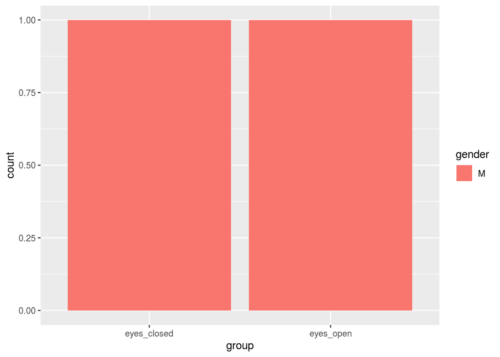

```r
#visual
ggplot(data = roster_ra, aes(x=group, fill=gender))+
  geom_bar()
```

```r
#numerical (the 1 mean the % is calculated by the row)
  prop.table(table(roster_ra$group, roster_ra$gender),1)
```

```
##
##               M
##   eyes_closed 1
##   eyes_open   1
```

## Practice visualization for additional categorical variables

Categorical Variable #2

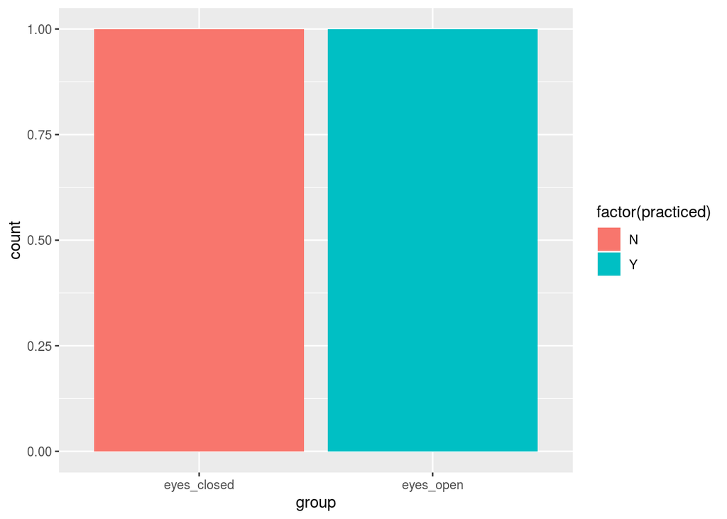

```r
ggplot(data = roster_ra, aes(x=group, fill=factor(practiced)))+
  geom_bar()
```

## Practice with other categorical variables

Categorical Variable #3 **amt_stress**

Categorical Variable #3 **fitness_level**

## Compare the groups with respect to the numerical variables

Example: Visualize **age** distribution for each group

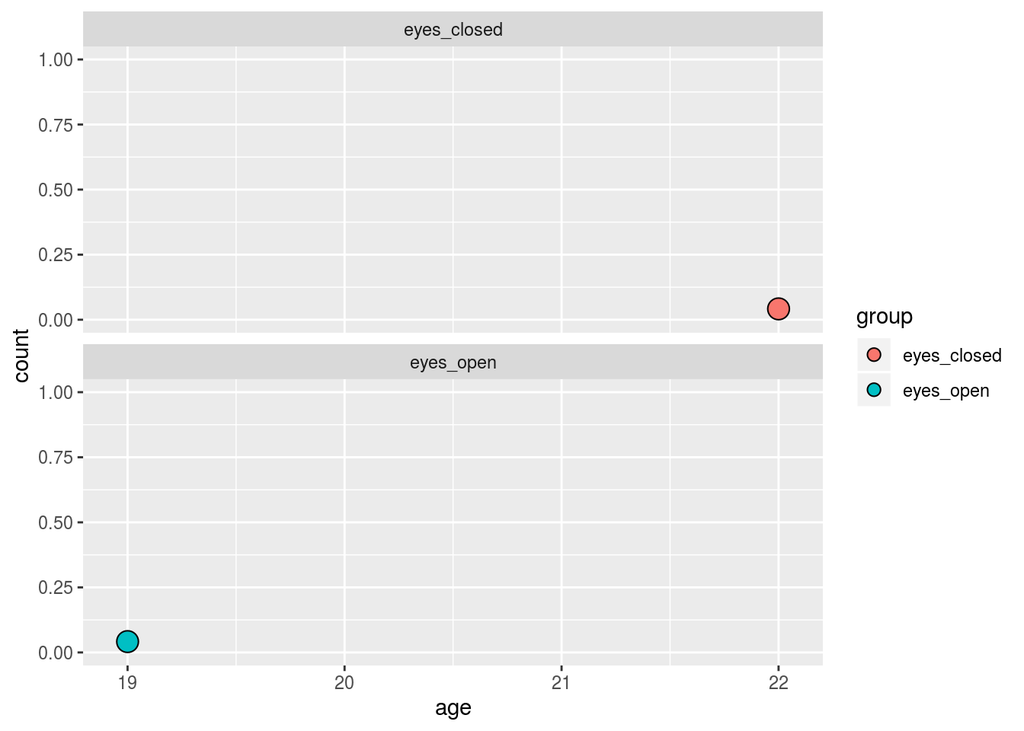

```r
ggplot(roster_ra, aes(x=age, fill=group))+
  geom_dotplot()+
  facet_wrap(~group, nrow=2)
```

```r
roster_ra %>%
  group_by(group) %>%
  summarise(mean=mean(height))
```

```
## # A tibble: 2 x 2
##   group        mean
##   <fct>       <dbl>
## 1 eyes_closed    67
## 2 eyes_open      56
```

## Practice - analyze the other numerical variable

Visualize

Calculate averages

## Analysis of the experimental results

#Re-Read in the data After study participants have edited their survey to include their time, reload the Google Sheet

```r
breath <-read.csv("https://docs.google.com/spreadsheets/d/e/2PACX-1vShIAfdrl33WvTe9fFLHZPZH1RSQpaBFc1e_EjlbfOC_-pW3mIb0vm0ugZrlFu4B72XiYBCHYnW33DW/pub?gid=839563195&single=true&output=csv")
```

# Compare the Treatment to the Control

Looking at differences in breathing time between control and treatment groups, using dotplot of each group

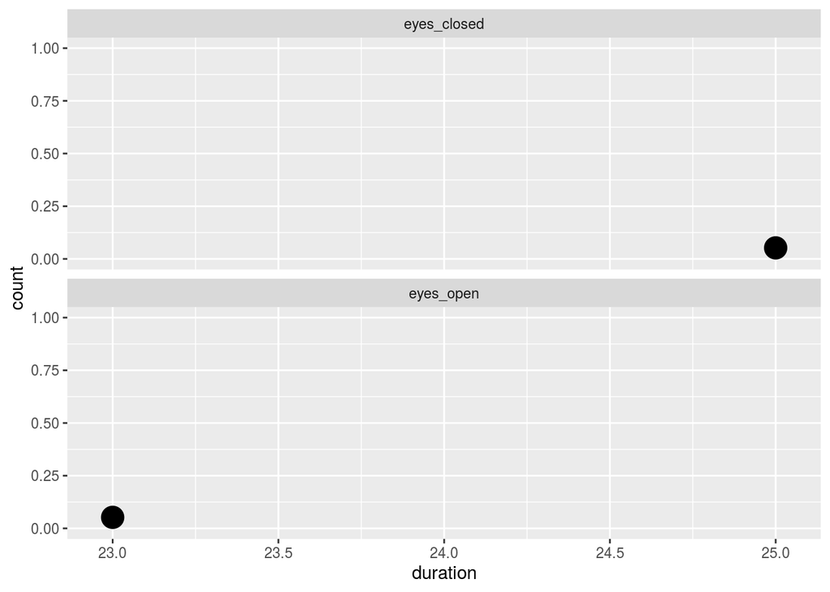

```r
ggplot(data=breath, aes(x=duration))+
  geom_dotplot()+
  facet_wrap(~group, nrow=2)
```

Another way to see the difference is to use a boxplot summary graphic

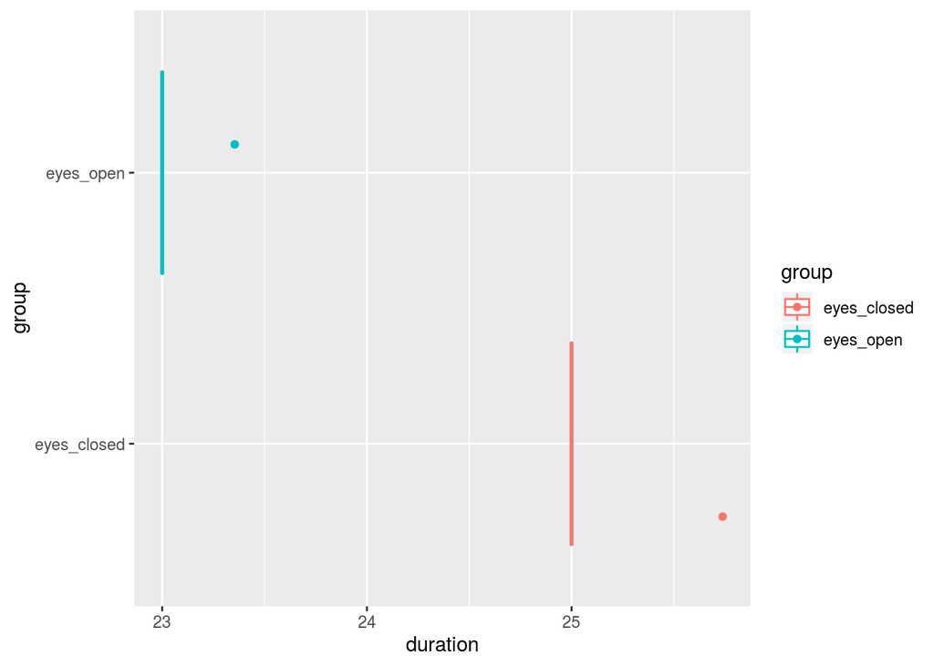

```r
ggplot(data=breath, aes(x=group, y=duration, color=group))+
  geom_boxplot()+
  geom_point(position="jitter")+
  coord_flip()
```

We can also compare averages time by looking at numerical summary broken down by group

```r
breath %>%
  group_by(group) %>%
  summarize(mean=mean(duration, NA.RM=TRUE))
```

```
## # A tibble: 2 x 2
##   group        mean
##   <fct>       <dbl>
## 1 eyes_closed    25
## 2 eyes_open      23
```

**Group Discusssion prompt: What do you notice?**

# Looking deeper into the categorical variables for differences within factors

Do we see any difference across categorical variable from control to treatment?

Example: differences within **gender** across the treatment/control

Numerical Summaries ( mean)

```r
breath %>%
  group_by(gender, group) %>%
  summarize(mean=mean(duration))
```

```
## # A tibble: 2 x 3
## # Groups:   gender [1]
##   gender group        mean
##   <fct>  <fct>       <dbl>
## 1 M      eyes_closed    25
## 2 M      eyes_open      23
```

Visualize the results with a dotplot

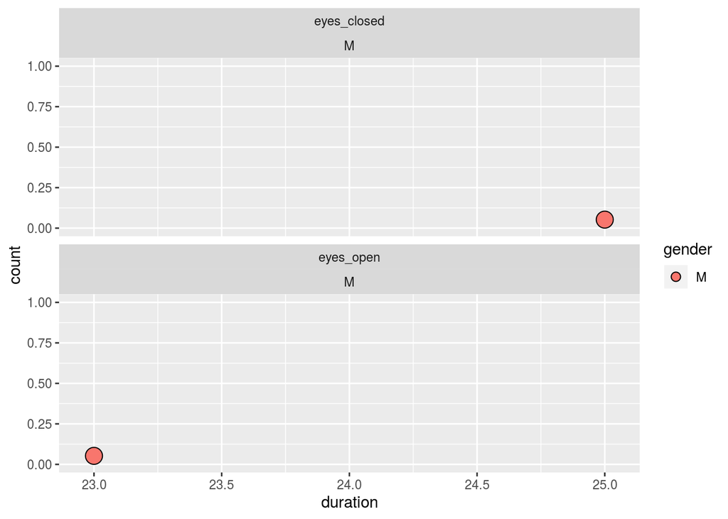

```r
ggplot(data=breath, aes( x=duration, fill=gender))+
  geom_dotplot()+
  facet_wrap(group~gender, nrow=2)
```

How is this different? When would I want this instead?

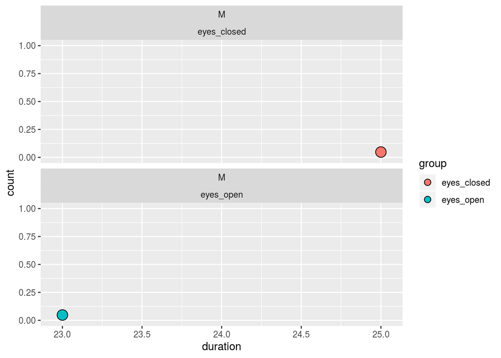

```r
ggplot(data=breath, aes( x=duration, fill=group))+
  geom_dotplot()+
  facet_wrap(gender~group, nrow=2)
```

## Additional Practice

Now let’s try to modify the above analysis for other categorical variables.